# Simulación de Variables Aleatorias: Distribución Beta

Método de Aceptación y Rechazo y Pruebas de Bondad de Ajuste

Autores/as

Luis Ríos

Sebastian Zabala

# 1. Introducción y Definición de Parámetros

En este trabajo se realiza la simulación de una variable aleatoria continua con distribución **Beta**. Se generarán 100 conjuntos de datos (simulaciones), cada uno compuesto por 100 números aleatorios.

Se ha seleccionado la distribución **Beta(**$\alpha, \beta$) debido a su dominio acotado en $[0,1]$, lo cual facilita la implementación del método de Aceptación y Rechazo utilizando una distribución Uniforme como auxiliar.

## 1.1 Parámetros de la Distribución

Para este experimento, hemos fijado los siguientes parámetros para garantizar una forma de campana asimétrica:

- $\alpha$ (alpha): 2
- $\beta$ (beta): 4

A partir de estos valores, calculamos la media y la varianza teórica poblacional, necesarias para las pruebas estadísticas posteriores (específicamente la prueba Z).

La fórmula para calcular la media de una variable aleatoria con distribución beta es la siguiente:

$$\begin{equation}
\frac{\alpha}{\alpha+\beta}
\end{equation}$$

Por otro lado, la fórmula para calcular la varianza de una de una variable aleatoria con distribution beta es la siguiente:

$$\begin{equation}
\frac{\alpha\beta}{(\alpha+\beta)^2(\alpha+\beta+1)}
\end{equation}$$

Se calculan la media y varianza teórica sustiyendo los valores de alpha y beta utilizando el siguiente script de R:

**Código**

```r
# 1. PARÁMETROS DE LA DISTRIBUCIÓN
alpha_param <- 2
beta_param  <- 4

n_nums <- 100      # Tamaño de la muestra (n)
n_sims <- 100      # Cantidad de simulaciones

# CÁLCULOS TEÓRICOS POBLACIONALES
# Media = a / (a + b)
media_teorica <- alpha_param / (alpha_param + beta_param)

# Varianza = (a * b) / ( (a + b)^2 * (a + b + 1) )
var_teorica <- (alpha_param * beta_param) /
               ((alpha_param + beta_param)^2 * (alpha_param + beta_param + 1))

# Desviación Estándar
desv_std_teorica <- sqrt(var_teorica)

cat("Media Teórica:", round(media_teorica, 4), "\n")
```

```
Media Teórica: 0.3333
```

**Código**

```r
cat("Desv. Estándar Teórica:", round(desv_std_teorica, 4))
```

```
Desv. Estándar Teórica: 0.1782
```

Como se puede observar, la media y desviación estándar teórica es de 0,3333 y 0,1782, respectivamente.

# 2. Metodología: Aceptación y Rechazo

**Idea general del método:** El método de Aceptación y Rechazo permite generar variables aleatorias con función de densidad $f(x)$ usando una variable auxiliar con densidad $g(x)$ y una constante $c$ tal que $f(x) \leq c⋅g(x$) para todo $x$. De acuerdo a esto, se tienen los siguientes elementos para nuestra simulación:

- Función Objetivo $f(x)$: Densidad $Beta(2, 4)$.
- Función Propuesta $g(x)$: Densidad $U(0, 1)$.
- Cálculo de c : Se obtiene evaluando en la moda de la distribución $Beta$ para maximizar la eficiencia.

Se recuerda que la moda de una variable aleatoria beta es la siguiente:

$$\begin{equation}
\frac{\alpha - 1}{\alpha + \beta - 2}
\end{equation}$$

En el siguiente script de R se definen las funciones $f(x)$, $g(x)$ y se calcula el valor de $c$.

**Código**

```r
# Definición de f(x) y g(x)
f <- function(x) { dbeta(x, shape1 = alpha_param, shape2 = beta_param) }
g <- function(x) { dunif(x, min = 0, max = 1) }

# Cálculo de la constante c (Maximizacion)
moda <- (alpha_param - 1) / (alpha_param + beta_param - 2)
c_val <- f(moda) / g(moda)

# Función del Algoritmo
generar_aceptacion_rechazo <- function(n) {
  aceptados <- numeric(n)
  count <- 0
  iteraciones_totales <- 0
  while(count < n) {
    iteraciones_totales <- iteraciones_totales + 1
    # 1. Generar R1 de g(x) -> Uniforme(0,1)
    r1 <- runif(1)
    # 2. Generar R2 de Uniforme(0,1) para el criterio
    r2 <- runif(1)

    # 3. Criterio de aceptación
    if (r2 <= f(r1) / (c_val * g(r1))) {
      count <- count + 1
      aceptados[count] <- r1
    }
  }
  # cat("Total iteraciones para conseguir", n, "muestras", iteraciones_totales, "\n")
  return(aceptados)
}
```

De igual manera, se define una función que retorna los números pseudoaletorios para la distribución beta, llamada `generar_aceptacion_rechazo(n)`.

# 3. Ejecución de la Simulación

A continuación, se generan las 100 simulaciones de tamaño 100 con una semilla de 123 mediante `seed(123)`:

**Código**

```r
set.seed(123) # Semilla para reproducibilidad
resultados <- matrix(NA, nrow = n_sims, ncol = n_nums)

for(i in 1:n_sims) {
  resultados[i, ] <- generar_aceptacion_rechazo(n_nums)
}
```

Se crea una matriz llamada $resultados_{100x100}$ para alojar a todos los números simulados. Esta inicialmente contiene NAs pero luego se va llenando en la medida en que se van aceptando valores a través del uso de la función `generar_aceptacion_rechazo().`

# 4. Pruebas de Bondad de Ajuste

Para validar los números generados, sometemos cada una de las 100 simulaciones a una batería de pruebas estadísticas con un nivel de confianza del 90% $(\alpha=0.10)$, 95% $(\alpha=0.05)$ y 99% $(\alpha=0.01)$.

Los p-valores obtenidos en cada simulación se comparan posteriormente con los niveles de significancia establecidos para determinar la proporción de rechazos empíricos.

## 4.1 Pruebas Estadísticas Aplicadas

Se aplican las siguientes pruebas:

- **Prueba de Medias (Z-Test)**: Contrasta si la media muestral difiere significativamente de la media teórica bajo el supuesto de normalidad asintótica (Teorema Central del Límite).
  $$\begin{align*}
  H_0 &: \mu = \mu_{\text{teórica}} \\
  H_1 &: \mu \neq \mu_{\text{teórica}}
  \end{align*}$$
  En nuestro caso:
  $$\begin{align*}
  H_0 &: \mu = 0.3333 \\
  H_1 &: \mu \neq 0.3333
  \end{align*}$$

Donde $\mu$ representa la media poblacional de la distribución Beta(2,4)..

El estadístico utilizado es:
$$\begin{equation}
Z = \frac{\bar{X} - \mu_{\text{teórica}}}{ \sigma / \sqrt{n}}
\end{equation}$$
Regla de decisión: Se rechaza $H_0$ si $|Z| > z_{1-\alpha/2}$, equivalentemente si el p-valor $< \alpha$.

- **Kolmogorov-Smirnov (KS)**: Evalúa si la función de distribución empírica difiere significativamente de la función de distribución acumulada teórica especificada.
  $$\begin{align*}
  H_0 &: F(x) = F_{Beta(\alpha, \beta)}(x) \\
  H_1 &: F(x) \neq F_{Beta(\alpha, \beta)}(x)
  \end{align*}$$
  En nuestro caso:
  $$\begin{align*}
  H_0 &: F(x) = F_{Beta(2, 4)}(x) \\
  H_1 &: F(x) \neq F_{Beta(2, 4)}(x)
  \end{align*}$$

Regla de decisión: Se rechaza $H_0$ si el estadístico KS excede el valor crítico correspondiente o si el p-valor $< \alpha$.

- **Prueba de Ljung-Box**: Contrasta si las autocorrelaciones muestrales hasta un rezago $k$ son conjuntamente iguales a cero, evaluando independencia serial.
  $$\begin{align*}
  H_0 &: \rho_1 = \rho_2 = \dots = \rho_k = 0 \\
  H_1 &: \exists j \text{ tal que } \rho_j \neq 0
  \end{align*}$$
  Regla de decisión: Se rechaza $H_0$ si el estadístico $Q$ supera el valor crítico $\chi^2_{k,,1-\alpha}$ o si el p-valor $< \alpha$.
- **Método Bootstrap para la varianza**: Evalúa si la varianza poblacional coincide con la varianza teórica utilizando la distribución empírica bootstrap para estimar su variabilidad.
  $$\begin{align*}
  H_0 &: \sigma^2 = \sigma^2_{teorica}\\
  H_1 &: \sigma^2 \neq \sigma^2_{teórica}
  \end{align*}$$
  Luego, la regla de decisión se basa en el intervalo de confianza bootstrap:
- Si $\sigma^2_{\text{teórica}} \in IC_{1-\alpha}^{boot}$ → No se rechaza $H_0$.
- Si $\sigma^2_{\text{teórica}} \notin IC_{1-\alpha}^{boot}$ → Se rechaza $H_0$.

En la implementación se utilizaron $B = 2000$ remuestreos bootstrap y se construyó un intervalo de confianza tipo BCa (Bias-Corrected and Accelerated). Este método corrige el sesgo y ajusta la asimetría de la distribución bootstrap, proporcionando intervalos más precisos cuando el estimador no es simétrico.

### 4.1.1 Justificación del uso del estadistico Z

Se aplica el estadístico Z por el Teorema Ceorema Central. El cual establece que la distribución de la media muestral se aproxima a una distribución normal a medida que el tamaño de la muestra aumenta, independientemente de la forma de la distribución original. En este caso, con n=100, se espera que la media muestral siga una distribución normal, lo que justifica el uso del estadístico Z para evaluar si la media muestral se desvía significativamente de la media teórica.

En el siguiente script de R se calcula la media muestral para cada una de las 100 simulaciones y se realiza un histograma de las medias muestrales para visualizar su distribución, superponiendo la curva normal teórica según el TCL y una línea vertical indicando la media teórica poblacional:

**Código**

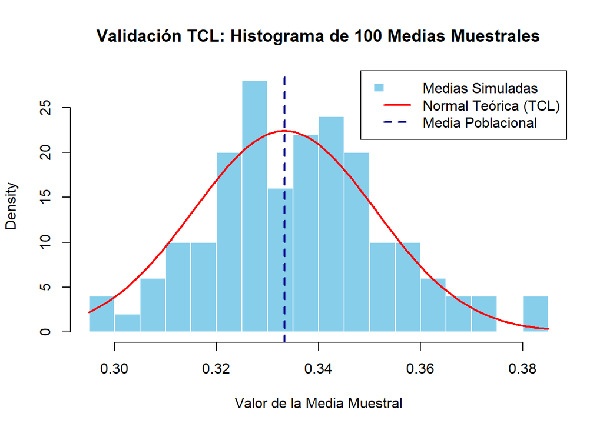

Figura 1: Validación del Teorema Central del Límite (TCL) para las Medias Muestrales de las Simulaciones.

```r
# 1. Calcular las medias de cada una de las simulaciones
# Opción eficiente: rowMeans calcula la media de cada fila (cada simulación)
medias_muestrales <- rowMeans(resultados)

# Con bucle for, sería así:
# medias_muestrales <- numeric(n_sims)
# for(i in 1:n_sims) {
#   medias_muestrales[i] <- mean(resultados[i, ])
# }

# 2. Generar el Histograma de las MEDIAS
hist(medias_muestrales,
     main = paste("Validación TCL: Histograma de", n_sims, "Medias Muestrales"),
     xlab = "Valor de la Media Muestral",
     border = "white",
     col = "skyblue",
     freq = FALSE, # Importante: Densidad para comparar con la curva
     breaks = 15
)

# 3. Superponer la Curva Normal Teórica
# El error estándar es la desviación de la población dividido por raíz de n
error_estandar <- desv_std_teorica / sqrt(n_nums)

# Graficamos la Normal centrada en la media teórica de la Beta
curve(dnorm(x, mean = media_teorica, sd = error_estandar),
      col = "red", lwd = 2, add = TRUE)

# 4. Línea de la media teórica (referencia visual)
abline(v = media_teorica, col = "darkblue", lwd = 2, lty = 2)

legend("topright",
       legend = c("Medias Simuladas", "Normal Teórica (TCL)", "Media Poblacional"),
       fill = c("skyblue", NA, NA),
       border = c("white", NA, NA),
       col = c(NA, "red", "darkblue"),
       lty = c(NA, 1, 2),
       lwd = c(NA, 2, 2))
```

Como se puede observar en la figura anterior, las medias muestrales se distribuyen alrededor de la media teórica poblacional (línea azul punteada) y la forma del histograma se asemeja a una campana de Gauss, lo cual es consistente con el Teorema Central del Límite. Esto justifica el uso del estadístico Z para la media muestral.

### 4.1.2 Justificación del Método Bootstrap para la Varianza

Para la validación de la dispersión de los datos, se evaluaron dos enfoques posibles. El primero consistía en aplicar la prueba de Chi-cuadrado sobre las medias muestrales ($\bar{X}$), aprovechando que estas convergen a una distribución Normal por el Teorema del Límite Central. Sin embargo, este enfoque valida la precisión del estimador (el error estándar, $\sigma^2/n$) y no necesariamente la estructura de varianza intrínseca de la población generada ($\sigma^2$). Es teóricamente posible que un generador defectuoso produzca medias estables que pasen una prueba de Chi-cuadrado, aun si la distribución subyacente no respeta la forma Beta.

Por esta razón, se optó por el segundo enfoque: validar la varianza de los datos originales ($X \sim Beta$) mediante el método Bootstrap. Dado que la distribución original es acotada y asimétrica (no normal), el Bootstrap (Efron, 1979) permite construir intervalos de confianza robustos para $\sigma^2$ sin depender de supuestos de normalidad asintótica que no aplican a la población base. De esta forma, se garantiza que el generador replica fielmente la dispersión teórica de la distribución Beta y no solo la convergencia de sus promedios. En ese sentido, esto permite contrastar si la varianza teórica poblacional se encuentra contenida dentro del intervalo de confianza generado a partir de la simulación, proporcionando una validación robusta de los resultados.

## 4.2 Ejecución de las Pruebas

La prueba de media, Kolmogorov-Smirnov y Ljung Box se aplican en el siguiente script de R:

**Código**

```r
# ==============================================================================
# 1. PREPARACIÓN DE ALMACENAMIENTO
# ==============================================================================
# Matriz para guardar los p-valores de cada prueba en cada simulación
# Filas = simulaciones, Columnas = pruebas
p_values_log <- data.frame(
  Z_Test_Promedios = numeric(n_sims),
  KS_Test          = numeric(n_sims),
  Box_Ljung        = numeric(n_sims)
)

# ==============================================================================
# 2. BUCLE DE PRUEBAS
# ==============================================================================
for(i in 1:n_sims) {
  datos <- resultados[i, ]
  media_muestral <- mean(datos)

  # --------------------------------------------------------
  # A. PRUEBA Z (Promedios con Varianza Conocida)
  # --------------------------------------------------------
  # H0: mu_muestral = mu_teorica
  z_stat <- (media_muestral - media_teorica) / (desv_std_teorica / sqrt(n_nums))
  p_val_z <- 2 * (1 - pnorm(abs(z_stat))) # P-valor Bilateral

  # --------------------------------------------------------
  # B. PRUEBA KOLMOGOROV-SMIRNOV (KS)
  # --------------------------------------------------------
  # H0: Los datos siguen la distribución Beta(alpha, beta)
  test_ks <- ks.test(datos, "pbeta", alpha_param, beta_param)

  # --------------------------------------------------------
  # C. PRUEBA BOX-LJUNG (Independencia)
  # --------------------------------------------------------
  # H0: Los datos son independientes (ruido blanco)
  # Lag sugerido: log(n) o 10. Para n=100, 10 está bien.
  test_box <- Box.test(datos, lag = 10, type = "Ljung-Box")

  # --------------------------------------------------------
  # ALMACENAMIENTO
  # --------------------------------------------------------
  p_values_log$Z_Test_Promedios[i] <- p_val_z
  p_values_log$KS_Test[i]          <- test_ks$p.value
  p_values_log$Box_Ljung[i]        <- test_box$p.value
}
```

En el siguiente script de R se realiza la prueba de varianza mediante bootstrap:

**Código**

```r
# ==============================================================================
# PRUEBA DE VARIANZA MEDIANTE BOOTSTRAP
# ==============================================================================
library(boot)

# 1. Función estadística para el bootstrap
var_fun <- function(data, indices) {
  return(var(data[indices]))
}

# 2. Ejecutar bootstrap (1000 réplicas es estándar, 2000 es mejor para publicación)
set.seed(123)
boot_results <- boot(data = datos, statistic = var_fun, R = 2000)

# 3. Calcular intervalo de confianza (BCa es ideal para asimetría como la Beta)
ci <- boot.ci(boot_results, type = "bca")

# 4. Extracción de los límites del intervalo
# La estructura de 'ci' en boot es una lista. El índice 4 y 5 del objeto 'bca' son los límites.
limite_inferior <- ci$bca[4]
limite_superior <- ci$bca[5]

# 5. Imprimir Resultados y Decisión Automática
cat("\n--- RESULTADOS BOOTSTRAP PARA LA VARIANZA ---\n")
```

```
--- RESULTADOS BOOTSTRAP PARA LA VARIANZA ---
```

**Código**

```r
cat("Varianza Teórica (Beta):", var_teorica, "\n")
```

```
Varianza Teórica (Beta): 0.03174603
```

**Código**

```r
cat("Intervalo de Confianza BCa (95%): [", round(limite_inferior, 5), ", ", round(limite_superior, 5), "]\n")
```

```
Intervalo de Confianza BCa (95%): [ 0.02341 ,  0.0396 ]
```

**Código**

```r
if (var_teorica >= limite_inferior && var_teorica <= limite_superior) {
  cat("DECISIÓN: NO SE RECHAZA la varianza teórica.\n")
  cat("CONCLUSIÓN: La varianza de los datos simulados es consistente con la teoría.\n")
} else {
  cat("DECISIÓN: SE RECHAZA la varianza teórica.\n") # (Esto sería raro si tu generador está bien)
}
```

```
DECISIÓN: NO SE RECHAZA la varianza teórica.
CONCLUSIÓN: La varianza de los datos simulados es consistente con la teoría.
```

Se complementa lo anterior con el histograma de las varianzas simuladas y un gráfico Q-Q Normal en el siguiente script de R:

**Código**

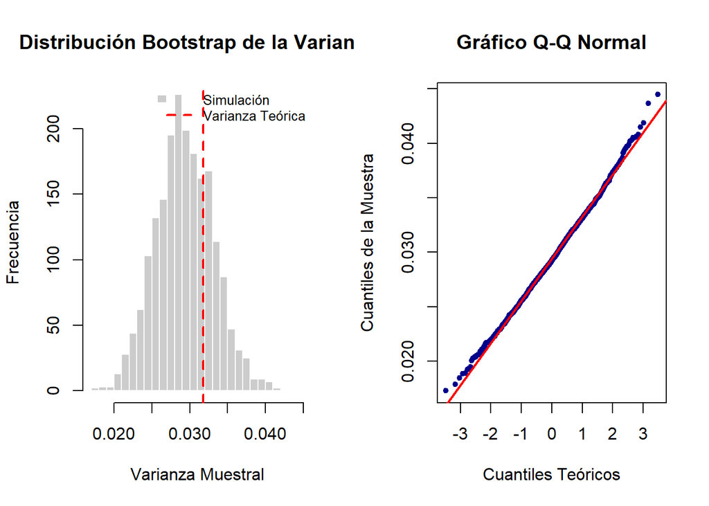

Figura 2: Gráfico diagnóstico del método Bootstrap para la varianza muestral. El histograma muestra la distribución de las varianzas simuladas, con una línea vertical roja indicando la varianza teórica poblacional.

```r
# Extraer los valores simulados de varianza
# boot_results$t contiene la matriz de resultados (R x 1)
varianzas_simuladas <- boot_results$t[,1]

# Configurar el área de gráfico: 1 fila, 2 columnas
par(mfrow = c(1, 2))

hist(varianzas_simuladas,
     main = "Distribución Bootstrap de la Varianza", # Título limpio
     xlab = "Varianza Muestral",
     ylab = "Frecuencia",
     col = "gray80",
     border = "white",
     breaks = 30) # Más barras para mejor detalle

abline(v = var_teorica, col = "red", lwd = 2, lty = 2)

# Leyenda (opcional, ajustada para que no tape datos)
legend("topright", legend = c("Simulación", "Varianza Teórica"),
       fill = c("gray80", NA), border = c("white", NA),
       col = c(NA, "red"), lty = c(NA, 2), lwd = c(NA, 2),
       bty = "n", cex = 0.8)

# Sirve para justificar la normalidad (o falta de ella)
qqnorm(varianzas_simuladas,
       main = "Gráfico Q-Q Normal",
       xlab = "Cuantiles Teóricos",
       ylab = "Cuantiles de la Muestra",
       pch = 20, col = "darkblue") # Puntos sólidos azules

qqline(varianzas_simuladas, col = "red", lwd = 2) # Línea de referencia normal

# 3. Restaurar configuración original de gráficos
par(mfrow = c(1, 1))
```

# 5. Análisis Gráfico para una simulación y Resultados Generales

En esta sección se analizan los gráficos de diagnosticos usuales y se culmina con los resultados generales obtenidos con los números pseudoaleatorios generados de la distribución $Beta(\alpha=2, \beta=4)$.

# 5.1 Gráficos de Diagnóstico

Se presentan los gráficos correspondientes a la última simulación realizada para visualizar el comportamiento de los datos.

**Código**

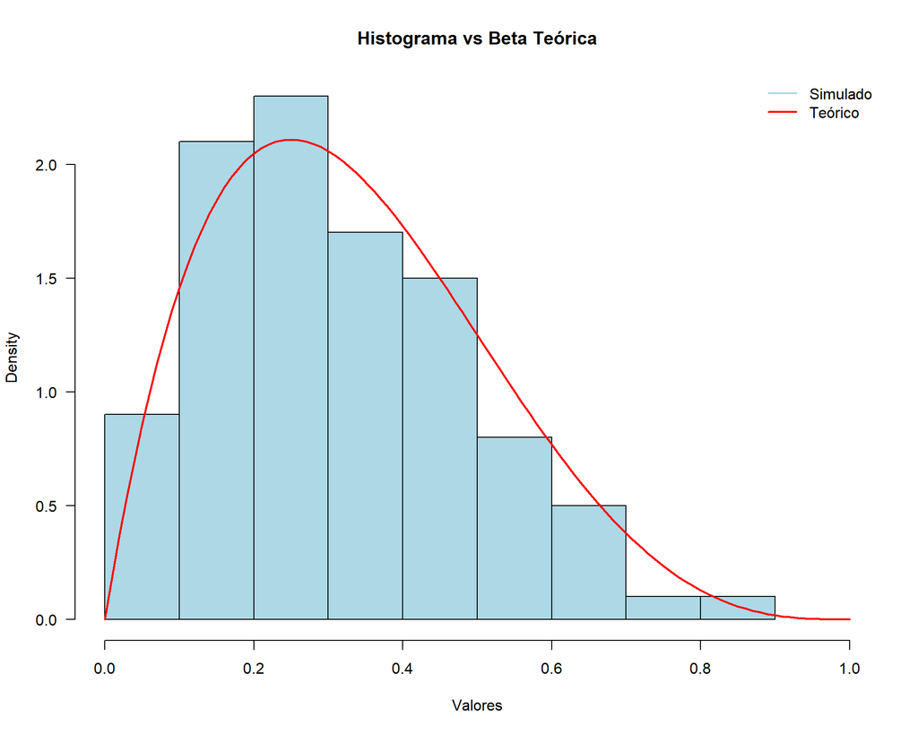

Figura 3: Histograma de los datos contra la distribución de una beta con esos parámetros.

```r
datos_grafico <- resultados[n_sims, ]

# Histograma vs Densidad Teórica
hist(datos_grafico, freq=FALSE, main="Histograma vs Beta Teórica",
     xlab="Valores", col="lightblue", xlim=c(0,1), las=1)
curve(dbeta(x, alpha_param, beta_param), add=TRUE, col="red", lwd=2)
legend("topright", legend=c("Simulado", "Teórico"), col=c("lightblue", "red"), lwd=2, bty="n")
```

Se observa que existe un buen ajuste de los datos simulados a la distribución teórica, aunque se nota una ligera desviación en la cola derecha, lo cual es consistente con la asimetría de la distribución $Beta(2,4)$.

**Código**

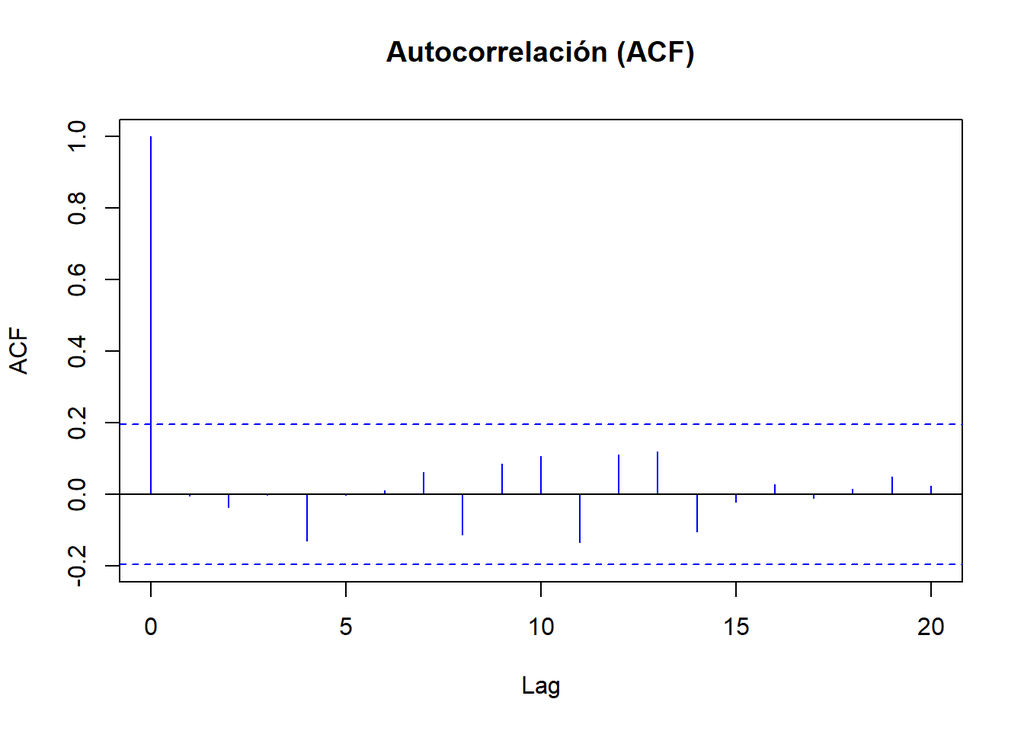

Figura 4: Gráfico de Autocorrelación (ACF) de la última simulación. Las líneas punteadas azules indican los límites de confianza del 95% para la hipótesis de independencia (Ruido Blanco).

```r
# par(mfrow=c(2,2)) # Dividir pantalla en 4 paneles

# Gráfico de Autocorrelación
acf(datos_grafico, main="Autocorrelación (ACF)", col="blue")

# par(mfrow=c(1,1)) # Resetear pantalla
```

No se observan rezagos significativos, lo cual sugiere que los datos no presentan autocorrelación serial y se comportan como ruido blanco.

**Código**

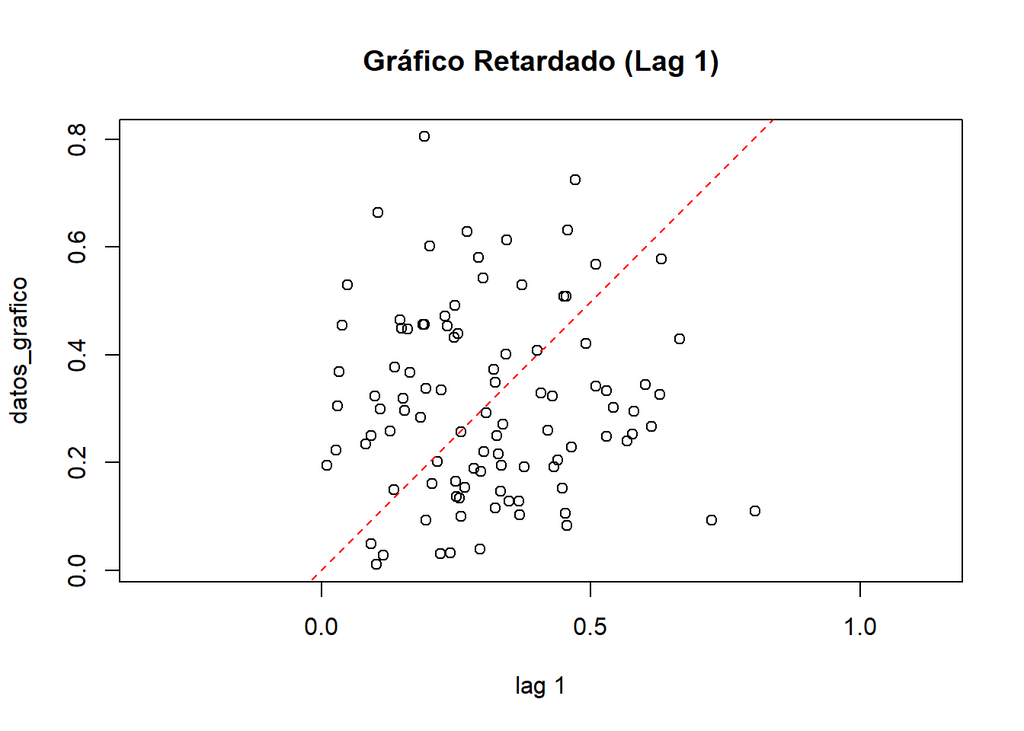

Figura 5: Gráfico de dispersión retardado (Lag Plot) con k=1 para la última simulación. Se compara cada observación $X_t$ contra su inmediata anterior $X_{t-1}$. La dispersión aleatoria sin patrones lineales confirma la falta de autocorrelación serial.

```r
# Gráfico Retardado (Lag Plot)
lag.plot(datos_grafico, lags=1, do.lines=FALSE, main="Gráfico Retardado (Lag 1)", diag.col="red")
```

Los datos se distribuyen de manera aleatoria sin formar patrones lineales, lo cual es consistente con la hipótesis de independencia entre observaciones.

# 5.2 Resultados

A continuación, en la tabla se muestra el resumen de cuántas simulaciones pasaron las pruebas satisfactoriamente:

**Código**

```r
library(gt)
library(dplyr)

# 1. PREPARAR DATOS (Resumen de Aprobados)
# Creamos un dataframe limpio calculando cuántas pasaron cada nivel
df_resumen <- data.frame(
  Prueba = c("Promedios (Z-Test)",
             "Kolmogorov-Smirnov",
             "Box-Ljung (Indep.)"),

  Alpha_0_10 = c(sum(p_values_log$Z_Test_Promedios > 0.10),
                 sum(p_values_log$KS_Test > 0.10),
                 sum(p_values_log$Box_Ljung > 0.10)),

  Alpha_0_05 = c(sum(p_values_log$Z_Test_Promedios > 0.05),
                 sum(p_values_log$KS_Test > 0.05),
                 sum(p_values_log$Box_Ljung > 0.05)),

  Alpha_0_01 = c(sum(p_values_log$Z_Test_Promedios > 0.01),
                 sum(p_values_log$KS_Test > 0.01),
                 sum(p_values_log$Box_Ljung > 0.01))
)

# 2. CREAR TABLA CON ESTILO 'gt'
df_resumen %>%
  gt() %>%
  # --- Encabezado ---
  tab_header(
    title = md("**Resultados de las Pruebas de Bondad de Ajuste**"),
    subtitle = "Conteo de simulaciones que NO rechazan la Hipótesis Nula (H0)"
  ) %>%

  # --- Agrupar columnas de Alpha ---
  tab_spanner(
    label = "Nivel de Significancia",
    columns = c(Alpha_0_10, Alpha_0_05, Alpha_0_01)
  ) %>%

  # --- Renombrar columnas para que se vean bonitas ---
  cols_label(
    Prueba = "Prueba Estadística",
    Alpha_0_10 = "α = 0.10",
    Alpha_0_05 = "α = 0.05",
    Alpha_0_01 = "α = 0.01"
  ) %>%

  # --- Alineación y Estilo de Texto ---
  cols_align(
    align = "center",
    columns = c(Alpha_0_10, Alpha_0_05, Alpha_0_01)
  ) %>%

  # --- Formato de color condicional (Opcional pero recomendado) ---
  # Pone en negrita verde si pasaron 95 o más pruebas (Excelente)
  # Pone en rojo si pasaron menos de 90 (Alerta)
  data_color(
    columns = c(Alpha_0_10, Alpha_0_05, Alpha_0_01),
    method = "numeric",
    palette = c("red", "white", "green"),
    domain = c(80, 100) # Rango esperado de simulaciones aprobadas
  ) %>%

  # --- Nota al pie ---
  tab_source_note(
    source_note = md("*Nota: Se realizaron 100 simulaciones con n=100 cada una. Un conteo alto indica un buen ajuste del generador.*")
  ) %>%

  # --- Bordes y tema ---
  opt_table_lines(extent = "default") %>%
  tab_options(
    table.border.top.color = "black",
    heading.border.bottom.color = "black",
    column_labels.border.bottom.color = "black"
  )
```

**Resultados de las Pruebas de Bondad de Ajuste**

Conteo de simulaciones que NO rechazan la Hipótesis Nula (H0)

| Prueba Estadística | Nivel de Significancia α = 0.10 | Nivel de Significancia α = 0.05 | Nivel de Significancia α = 0.01 |
| --- | --- | --- | --- |
| Promedios (Z-Test) | 91 | 94 | 98 |
| Kolmogorov-Smirnov | 86 | 95 | 99 |
| Box-Ljung (Indep.) | 82 | 90 | 96 |

*Nota: Se realizaron 100 simulaciones con n=100 cada una. Un conteo alto indica un buen ajuste del generador.*

Se observa que para las tres pruebas consideradas se tienen buenos resultados, no rechazando en la mayoría de las ocasiones la hipótesis nula, siendo consistentes con la variabilidad muestral esperada.

# 6. Conclusión

El generador de números aleatorios basado en el método de Aceptación y Rechazo ha demostrado ser eficaz para simular la distribución Beta. Las pruebas de bondad de ajuste confirman que los datos generados replican fielmente la estructura teórica:

**Recomendación Final**: El generador es apto para su uso. Se sugiere, como medida de precaución en aplicaciones de alta sensibilidad, verificar la independencia de las series generadas mediante la prueba de Ljung-Box o aumentar el tamaño de la muestra para diluir posibles autocorrelaciones residuales.